# Wagner2Vek: Die Meistersinger von Nürnberg

Word2Vecによる[楽劇「ニュルンベルクのマイスタージンガー」](https://ja.wikipedia.org/wiki/%E3%83%8B%E3%83%A5%E3%83%AB%E3%83%B3%E3%83%99%E3%83%AB%E3%82%AF%E3%81%AE%E3%83%9E%E3%82%A4%E3%82%B9%E3%82%BF%E3%83%BC%E3%82%B8%E3%83%B3%E3%82%AC%E3%83%BC)（リヒャルト・ワーグナー作曲のオペラ）のドイツ語歌詞の解析と関係性可視化の試み

## ライブラリの読込

```python
%matplotlib inline
# スクレイピング・データ整形
import requests
from bs4 import BeautifulSoup
import re
import pandas as pd
# NLP
import spacy
import hashlib
import gensim
import codecs
from gensim.models import word2vec
from gensim.models.phrases import Phrases, Phraser
# ネットワーク図作成
import networkx as nx
import matplotlib.pyplot as plt
from bokeh.io import show, output_notebook
from bokeh.plotting import figure
from bokeh.models import Plot, Range1d, MultiLine, Circle,\
                         HoverTool, BoxZoomTool, ResetTool, TapTool, BoxSelectTool, WheelZoomTool, PanTool, SaveTool,\
                         ColumnDataSource, LabelSet
from bokeh.models.graphs import from_networkx, NodesAndLinkedEdges, EdgesAndLinkedNodes
from bokeh.palettes import Spectral4
```

## スクレイピング・データ整形用の関数を定義

```python
def remove_headfoot(responce):
    """
    Remove headers and footers from a responce

    Arguments
    responce: responce of requests.get()

    Return values
    text: text without headers and footers
    """
    responce.encoding = responce.apparent_encoding
    text = re.sub('(<br />|\s{2,})(?=[0-9\u00c4\u00d6\u00dc\u00dfA-Z][\s.0-9\u00c4\u00d6\u00dc\u00dfA-Z]{2,}<br />)', '<br /><br />',
              re.sub('<tr valign="top"><td>libretto by.+', '',
                     re.findall('<span class="act".+', re.sub('[\n\r\t]', '', responce.text))[0]))
    return text
```

```python
def text2df(text):
    """
    Shape and cleanse text into a dataframe

    Arguments
    text: output of extract_text()

    Return Values
    df: a dataframe into which the text gets shaped
    """
    df = pd.DataFrame()
    texts = text.split('<b>')
    aufzug = BeautifulSoup(texts.pop(0)).text
    print(aufzug)
    for t in texts:
        szene = t.split('</b>')[0]
        print(szene)
        script = re.sub('(<br />)?<i>([\w\s\(\)\[\];,:.-]|<br />|</?t(d|r)[\w\s"=/]*>)+</i>', '', t.split('</b>')[1]).split('<br /><br />')
        for s in script:
            if s not in (None, ''):
                s_list = re.sub('^<br />', '', s).split('<br />')
                if len(s_list) > 1:
                    name = re.sub('<[\w\s"=/]+>|\s{2,}', '', s_list.pop(0))
                    s_text = re.sub('<[\w\s"=/]+>|\s{2,}', '', ' '.join(s_list))
                    df = pd.concat([df, pd.DataFrame({'aufzug': aufzug, 'szene': szene, 'name': name, 'text': s_text}, index=['szene'])])
    return df.reset_index(drop=True)
```

## データ取得・整形

```python
dat = pd.DataFrame()
for i in range(1, 4):
    res = requests.get(f'http://www.murashev.com/opera/Die_Meistersinger_von_N%C3%BCrnberg_libretto_German_Act_{i}')
    text = remove_headfoot(res)
    dat = pd.concat([dat, text2df(text)])
```

```
ERSTER AUFZUG
ERSTE SZENE
ZWEITE SZENE
DRITTE SZENE
ZWEITER AUFZUG
ERSTE SZENE
ZWEITE SZENE
DRITTE SZENE
VIERTE SZENE
FÜNFTE SZENE
SECHSTE SZENE
SIEBENTE SZENE
DRITTER AUFZUG
VORSPIEL
ERSTE SZENE
ZWEITE SZENE
DRITTE SZENE
VIERTE SZENE
FÜNFTE SZENE
```

内容を確認。

```python
dat
```

|  | aufzug | szene | name | text |
| --- | --- | --- | --- | --- |
| 0 | ERSTER AUFZUG | ERSTE SZENE | CHORAL DER GEMEINDE | Da zu dir der Heiland kam, willig seine Taufe ... |
| 1 | ERSTER AUFZUG | ERSTE SZENE | WALTHER | Verweilt! Ein Wort! Ein einzig Wort! |
| 2 | ERSTER AUFZUG | ERSTE SZENE | EVA | Mein Brusttuch! schau! Wohl liegt's im Ort - |
| 3 | ERSTER AUFZUG | ERSTE SZENE | MAGDALENE | Vergesslich Kind! Nun heisst es: such'! |
| 4 | ERSTER AUFZUG | ERSTE SZENE | WALTHER | Fräulein, verzeiht der Sitte Bruch. Eines zu w... |
| 5 | ERSTER AUFZUG | ERSTE SZENE | MAGDALENE | Hier ist das Tuch. |
| 6 | ERSTER AUFZUG | ERSTE SZENE | EVA | O weh! Die Spange. |
| 7 | ERSTER AUFZUG | ERSTE SZENE | MAGDALENE | Fiel sie wohl ab? |
| 8 | ERSTER AUFZUG | ERSTE SZENE | WALTHER | Ob Licht und Lust, oder Nacht und Grab? Ob ich... |
| 9 | ERSTER AUFZUG | ERSTE SZENE | MAGDALENE | Da ist auch die Spange. - Komm, Kind! Nun hast... |
| 10 | ERSTER AUFZUG | ERSTE SZENE | WALTHER | Dies eine Wort, ihr sagt mir's nicht? Die Silb... |
| 11 | ERSTER AUFZUG | ERSTE SZENE | MAGDALENE | Sieh da! Herr Ritter? Wie sind wir hochgeehrt:... |
| 12 | ERSTER AUFZUG | ERSTE SZENE | WALTHER | O, betrat ich doch nie sein Haus! |
| 13 | ERSTER AUFZUG | ERSTE SZENE | MAGDALENE | Ei! Junker, was sagt ihr da aus? In Nürnberg e... |
| 14 | ERSTER AUFZUG | ERSTE SZENE | EVA | Gut Lenchen, ach! das meint er ja nicht; doch ... |
| 15 | ERSTER AUFZUG | ERSTE SZENE | MAGDALENE | Hilf Gott! Sprich nicht so laut! jetzt lass un... |
| 16 | ERSTER AUFZUG | ERSTE SZENE | WALTHER | Nicht eh'r, bis ich alles weiss! |
| 17 | ERSTER AUFZUG | ERSTE SZENE | EVA | 's ist leer, die Leut' sind fort. |
| 18 | ERSTER AUFZUG | ERSTE SZENE | MAGDALENE | Drum eben wird mir heiss! Herr Ritter, an andr... |
| 19 | ERSTER AUFZUG | ERSTE SZENE | WALTHER | Nein! Erst dies Wort! |
| 20 | ERSTER AUFZUG | ERSTE SZENE | EVA | Dies Wort? |
| 21 | ERSTER AUFZUG | ERSTE SZENE | MAGDALENE | David! Ei! David hier? |
| 22 | ERSTER AUFZUG | ERSTE SZENE | EVA | Was sag' ich? Sag' du's mir! |
| 23 | ERSTER AUFZUG | ERSTE SZENE | MAGDALENE | Herr Ritter, was ihr die Jungfer fragt, das is... |
| 24 | ERSTER AUFZUG | ERSTE SZENE | EVA | Doch hat noch keiner den Bräut'gam erschaut! |
| 25 | ERSTER AUFZUG | ERSTE SZENE | MAGDALENE | Den Bräut'gam wohl noch niemand kennt, bis mor... |
| 26 | ERSTER AUFZUG | ERSTE SZENE | EVA | Und selbst die Braut ihm reicht das Reis. |
| 27 | ERSTER AUFZUG | ERSTE SZENE | WALTHER | Dem Meistersinger? |
| 28 | ERSTER AUFZUG | ERSTE SZENE | EVA | Seid ihr das nicht? |
| 29 | ERSTER AUFZUG | ERSTE SZENE | WALTHER | Ein Werbgesang? |
| ... | ... | ... | ... | ... |
| 191 | DRITTER AUFZUG | FÜNFTE SZENE | ORTEL UND FOLTZ | Welch' eigner Fall! |
| 192 | DRITTER AUFZUG | FÜNFTE SZENE | SACHS | Das Lied, fürwahr, ist nicht von mir: Herr Bec... |
| 193 | DRITTER AUFZUG | FÜNFTE SZENE | DIE MEISTERSINGER | Wie? Schön das Lied? Der Unsinns-Wust? |
| 194 | DRITTER AUFZUG | FÜNFTE SZENE | VOLK | Hört! Sachs macht Spass! Er sagt es nur zur Lust. |
| 195 | DRITTER AUFZUG | FÜNFTE SZENE | SACHS | Ich sag' euch Herrn, das Lied ist schön; nur i... |
| 196 | DRITTER AUFZUG | FÜNFTE SZENE | DIE MEISTERSINGER | Ei Sachs, ihr seid gar fein! Doch mag es heut'... |
| 197 | DRITTER AUFZUG | FÜNFTE SZENE | SACHS | Der Regel Güte daraus man erwägt, dass sie auc... |
| 198 | DRITTER AUFZUG | FÜNFTE SZENE | VOLK | Ein guter Zeuge, stolz und kühn; mich dünkt, d... |
| 199 | DRITTER AUFZUG | FÜNFTE SZENE | SACHS | Meister und Volk sind gewillt zu vernehmen, wa... |
| 200 | DRITTER AUFZUG | FÜNFTE SZENE | LEHRBUBEN | Alles gespannt! 's gibt kein Gesumm': da rufen... |
| 201 | DRITTER AUFZUG | FÜNFTE SZENE | WALTHER | "Morgenlich leuchtend im rosigen Schein, von B... |
| 202 | DRITTER AUFZUG | FÜNFTE SZENE | MEISTERSINGER | Ja wohl, ich merk', 's ist ein ander Ding, ob ... |
| 203 | DRITTER AUFZUG | FÜNFTE SZENE | VOLK | Das ist was andres, wer hätt's gedacht; was do... |
| 204 | DRITTER AUFZUG | FÜNFTE SZENE | SACHS | Zeuge am Ort, fahret fort! |
| 205 | DRITTER AUFZUG | FÜNFTE SZENE | WALTHER | "Abendlich dämmernd umschloss mich die Nacht; ... |
| 206 | DRITTER AUFZUG | FÜNFTE SZENE | MEISTERSINGER | 's ist kühn und seltsam, das ist wahr; doch wo... |
| 207 | DRITTER AUFZUG | FÜNFTE SZENE | VOLK | So hold und traut so fern es schwebt; doch ist... |
| 208 | DRITTER AUFZUG | FÜNFTE SZENE | SACHS | Zeuge, wohl erkiest; Fahret fort, und schliesst! |
| 209 | DRITTER AUFZUG | FÜNFTE SZENE | WALTHER | "Huldreichster Tag, dem ich aus Dichters Traum... |
| 210 | DRITTER AUFZUG | FÜNFTE SZENE | VOLK | Gewiegt wie in den schönsten Traum, hör' ich e... |
| 211 | DRITTER AUFZUG | FÜNFTE SZENE | DIE MEISTER | Ja, holder Sänger, nimm das Reis; dein Sang er... |
| 212 | DRITTER AUFZUG | FÜNFTE SZENE | POGNER | O Sachs! Dir dank' ich Glück und Ehr': vorüber... |
| 213 | DRITTER AUFZUG | FÜNFTE SZENE | EVA | Keiner wie du so hold zu werben weiss! |
| 214 | DRITTER AUFZUG | FÜNFTE SZENE | SACHS | Den Zeugen, denk' es, wählt' ich gut: tragt ih... |
| 215 | DRITTER AUFZUG | FÜNFTE SZENE | VOLK | Hans Sachs! Nein! Das war schön erdacht! Das h... |
| 216 | DRITTER AUFZUG | FÜNFTE SZENE | MEISTERSINGER | Auf, Meister Pogner! Euch zum Ruhm, meldet dem... |
| 217 | DRITTER AUFZUG | FÜNFTE SZENE | POGNER | Geschmückt mit König Davids Bild, nehm' ich eu... |
| 218 | DRITTER AUFZUG | FÜNFTE SZENE | WALTHER | Nicht Meister! Nein! Will ohne Meister selig s... |
| 219 | DRITTER AUFZUG | FÜNFTE SZENE | SACHS | Verachtet mir die Meister nicht, und ehrt mir ... |
| 220 | DRITTER AUFZUG | FÜNFTE SZENE | VOLK | Ehrt eure deutschen Meister, dann bannt ihr gu... |

801 rows × 4 columns

```python
for i, t in enumerate(dat.text):
    res = re.findall('[\s.0-9\u00c4\u00d6\u00dc\u00dfA-Z]{3,}', t)
    if len(res) > 0:
        print(i)
        print(res)
```

```
0
['. E']
4
['. E', '...']
8
['...']
9
['... O ']
23
['. F']
50
['. M']
53
['. W']
55
['. D']
57
['. F']
86
['O L']
88
['O M']
90
['. I', '. S', '. D']
92
['. U', '. W']
96
['. J', '. M', '. N', '. V', '. S', '. W']
107
['. E', '. D', '. S']
114
['. W']
118
['. V']
120
['. W']
129
['. D']
134
['. S']
```

[output cut: 211 more lines]

```
['. M']
772
['. W']
775
['. I', '. I']
779
['. H']
781
['. E']
790
['. R']
792
['O S']
799
['. N', '. D', '. D']
```

単語数

```python
len(' '.join(dat.text).split())
```

```
16141
```

## [spaCy](https://explosion.ai/blog/german-model)によるドイツ語テキスト処理

```python
de = spacy.load('de')
```

```python
dok = de(' '.join(dat.text))
#dok
```

```python
# 最初の20個のトークンについて処理結果を確認。
for t in dok[0:20]:
    print(t.text, t.norm_, t.lemma_, t.pos_, t.is_stop, t.is_alpha, t.is_punct)
```

```
Da da da ADV False True False
zu zu zu ADP True True False
dir dir sich PRON True True False
der der der DET True True False
Heiland heiland Heiland PROPN False True False
kam kam kommen VERB True True False
, , , PUNCT False False True
willig willig willig ADJ False True False
seine seine mein DET True True False
Taufe taufe Taufe NOUN False True False
nahm nahm nehmen VERB True True False
, , , PUNCT False False True
weihte weihte weihen VERB False True False
sich sich sich PRON True True False
dem dem der DET True True False
Opfertod opfertod Opfertod NOUN False True False
, , , PUNCT False False True
gab gab geben VERB True True False
er er ich PRON True True False
uns uns sich PRON True True False
```

```python
t_lemma = ''
for t in dok:
    if ~t.is_stop and t.is_alpha and t.pos_ in ['NOUN', 'VERB', 'ADJ', 'PROPN', 'ADV']:
        # ストップ語以外、アルファベットからなる語、品詞が名詞、動詞、形容詞、固有名詞、副詞。
        t_lemma = t_lemma + '\n' + t.lemma_
#t_lemma
```

```python
# with codecs.open("Meistersinger.txt", "w", "utf-8") as f:
#     f.write(t_lemma)

# with codecs.open("Meistersinger.txt", "r", "utf-8") as f:
#     corpus = f.read().splitlines()
#     print(corpus)
```

## gensimのWord2Vecを用いて、単語相互のsimilarityを算出

```python
corpus = [sentence.split() for sentence in t_lemma.splitlines()]
```

```python
# https://stackoverflow.com/questions/34831551/ensure-the-gensim-generate-the-same-word2vec-model-for-different-runs-on-the-sam/34849797
# gensimの再現性を確保するための自前ハッシュ関数
def dummyhash(string):
    hash_value = int(hashlib.sha256(string.encode()).hexdigest(), 16)
    return hash_value
```

```python
# モデルを作成
model = word2vec.Word2Vec(corpus, size=100, min_count=3, window=5, hs=1, negative=0,
                          # gensimの再現性を確保するための設定
                          workers=1, hashfxn=dummyhash)
```

```python
model.save('Meistersinger.model')
# 上で保存したモデルを読み込む: model = Word2Vec.load('Meistersinger.model')
```

モデルの内容を確認する。

```python
model.wv.vocab.keys()
```

```
dict_keys(['da', 'kommen', 'Taufe', 'nehmen', 'weihen', 'geben', 'Gebot', 'wert', 'dort', 'Jordan', 'Wort', 'einzig', 'Wohl', 'liegen', 'Ort', 'Kind', 'Nun', 'heisst', 'Fräulein', 'Bruch', 'wissen', 'fragen', 'müsst', 'brechen', 'wagen', 'Leben', 'vertrauen', 'sagen', 'Hier', 'O', 'wohl', 'Licht', '…
```

```python
len(model.wv.vocab.keys())
```

```
684
```

```python
model.wv['Walther']
```

```
array([ 0.00442194, -0.00201003, -0.00147538, -0.00196012, -0.00153767,
       -0.00442717, -0.00277035, -0.00364695,  0.00472021, -0.00494607,
       -0.00165588,  0.0042069 , -0.00376471,  0.00148012,  0.00342673,
        0.00273931, -0.00344558, -0.00369395, -0.00061749, -0.00397292,
        0.00487477,  0.00120018,  0.00395154, -0.000316  ,  0.0036352 ,
       -0.00085576, -0.00230499, -0.00476108,  0.00472589, -0.00061947,
       -0.00411484, -0.00127667, -0.00169091, -0.00458427, -0.00039572,
        0.00355952, -0.00242617, -0.00431572, -0.00114123, -0.00270527,
       -0.00230672, -0.00161435,  0.00334767,  0.0039234 , -0.00140781,
       -0.00049296,  0.00340537, -0.00314988,  0.00090166, -0.00215804,
        0.00201576, -0.00248295, -0.00205234,  0.00346181,  0.00011888,
        0.00160159,  0.0025362 ,  0.00226369,  0.00272002, -0.00129275,
       -0.00048919, -0.00140805,  0.00307381,  0.00029356, -0.00151785,
       -0.00094801,  0.00090223,  0.00232192,  0.00312414, -0.00408358,
       -0.00254486,  0.00376354,  0.00197258, -0.00198124,  0.00399658,
       -0.00419415, -0.00420664,  0.00215022, -0.00424763, -0.00495242,
        0.00053979, -0.00420276,  0.00456864, -0.00082709, -0.00065009,
       -0.00377939,  0.00125757, -0.00317055, -0.00031054, -0.00053405,
        0.00390343,  0.00230473, -0.00269764,  0.00410702,  0.00170862,
       -0.00109518, -0.00338518, -0.0044219 , -0.00484692,  0.00200559],
      dtype=float32)
```

単語間のsimilarity

```python
model.wv.similarity('Walther', 'Beckmesser')
```

```
0.03596978309773681
```

```python
model.wv.similarity('Walther', 'Sachs')
```

```
0.057208876041453
```

```python
model.wv.similarity('Walther', 'Meistersinger')
```

```
-0.07759305962630868
```

```python
model.wv.similarity('David', 'Meistersinger')
```

```
0.051510593796034704
```

```python
model.wv.similarity('Gott', 'Lied')
```

```
-0.06911376195266614
```

ある単語に近しい単語

```python
similar_words = model.wv.most_similar(positive=["Walther"], topn=10)
print(*[" ".join([v, str("{:.2f}".format(s))]) for v, s in similar_words], sep="\n")
```

```
Jahr 0.32
schreiten 0.30
dazu 0.26
heisst 0.26
Dann 0.24
Hei 0.22
süsse 0.22
Witz 0.21
Junker 0.21
eh 0.21
```

```python
similar_words = model.wv.most_similar(positive=["Stolzing"], topn=10)
print(*[" ".join([v, str("{:.2f}".format(s))]) for v, s in similar_words], sep="\n")
```

```
Herr 0.38
Vielleicht 0.32
Schuh 0.32
Takt 0.30
stillen 0.26
Ade 0.26
Stuhl 0.25
hausen 0.24
dumm 0.24
Wahn 0.23
```

```python
similar_words = model.wv.most_similar(positive=["Junker"], topn=10)
print(*[" ".join([v, str("{:.2f}".format(s))]) for v, s in similar_words], sep="\n")
```

```
geben 0.32
erdenken 0.30
kühn 0.26
regeln 0.25
Freund 0.25
schreiten 0.25
Dank 0.24
seh 0.24
Herr 0.23
freuen 0.22
```

```python
similar_words = model.wv.most_similar(positive=["Eva"], topn=10)
print(*[" ".join([v, str("{:.2f}".format(s))]) for v, s in similar_words], sep="\n")
```

```
dächt 0.32
Beschwerde 0.29
Füssen 0.28
glatt 0.28
gestern 0.28
Kopf 0.27
versang 0.26
oft 0.24
Wahl 0.24
hallo 0.23
```

```python
similar_words = model.wv.most_similar(positive=["Beckmesser"], topn=10)
print(*[" ".join([v, str("{:.2f}".format(s))]) for v, s in similar_words], sep="\n")
```

```
Teufel 0.28
etwa 0.28
gelten 0.27
streiten 0.27
Sachs 0.24
stolz 0.21
übel 0.20
Richter 0.20
wisst 0.19
nennen 0.19
```

```python
similar_words = model.wv.most_similar(positive=["Sachs"], topn=10)
print(*[" ".join([v, str("{:.2f}".format(s))]) for v, s in similar_words], sep="\n")
```

```
Teufel 0.33
kreisen 0.29
gestern 0.26
etwa 0.26
morgen 0.25
Beckmesser 0.24
hallo 0.23
böse 0.22
Bar 0.22
klug 0.22
```

```python
similar_words = model.wv.most_similar(positive=["David"], topn=10)
print(*[" ".join([v, str("{:.2f}".format(s))]) for v, s in similar_words], sep="\n")
```

```
Schwert 0.39
schmerzen 0.36
genug 0.31
Kies 0.28
darin 0.26
fasst 0.25
still 0.25
Vers 0.24
Beck 0.23
fassen 0.23
```

```python
similar_words = model.wv.most_similar(positive=["Lieb"], topn=10)
print(*[" ".join([v, str("{:.2f}".format(s))]) for v, s in similar_words], sep="\n")
```

```
langen 0.27
Schluss 0.27
genug 0.25
schneidern 0.24
fahren 0.24
Feind 0.23
Komm 0.23
fragen 0.22
Freundin 0.22
Zank 0.22
```

```python
similar_words = model.wv.most_similar(positive=["Lied"], topn=10)
print(*[" ".join([v, str("{:.2f}".format(s))]) for v, s in similar_words], sep="\n")
```

```
richt 0.31
wüsst 0.26
Gesang 0.26
Jordan 0.23
fasst 0.23
davon 0.22
Wettgesang 0.22
Dort 0.21
Auge 0.20
Taufe 0.20
```

2単語間の差分

```python
results = model.wv.most_similar(positive=['Walther'], negative=['Beckmesser'], topn=10)
for result in results:
    print(result)
```

```
('dazu', 0.34546202421188354)
('wähnen', 0.31116795539855957)
('Meister', 0.30161553621292114)
('Jahr', 0.2737889587879181)
('neu', 0.24289995431900024)
('Junker', 0.2399974763393402)
('schreiten', 0.23720328509807587)
('Meisterlied', 0.23618724942207336)
('freuen', 0.23415091633796692)
('dritt', 0.21885886788368225)
```

```python
results = model.wv.most_similar(positive=['Sachs'], negative=['Beckmesser'], topn=10)
for result in results:
    print(result)
```

```
('leicht', 0.28681787848472595)
('kreisen', 0.2638789415359497)
('Beschwer', 0.2516334354877472)
('Garten', 0.2511705160140991)
('weit', 0.2496204823255539)
('gestern', 0.24838677048683167)
('Kind', 0.24051949381828308)
('Jerum', 0.2219531387090683)
('morgen', 0.2168348729610443)
('Alte', 0.2111724615097046)
```

```python
results = model.wv.most_similar(positive=['Sachs'], negative=['Pogner'], topn=10)
for result in results:
    print(result)
```

```
('Teufel', 0.3174097537994385)
('hoch', 0.272392600774765)
('Bar', 0.25663185119628906)
('Wär', 0.23354312777519226)
('Schon', 0.23342682421207428)
('deut', 0.2247566133737564)
('liegen', 0.2218894064426422)
('Morgen', 0.2215660661458969)
('langen', 0.221276193857193)
('Ei', 0.2201652228832245)
```

## NetworkXとBokehによる可視化

```python
vokab = []
freq = []
for wort, vokab_obj in model.wv.vocab.items():
    if vokab_obj.count >= 20 or wort in ['Walther', 'Eva', 'Beckmesser', 'Sachs', 'Pogner', 'Meistersinger', 'David']:
        vokab += [wort]
        freq += [vokab_obj.count]
```

出現頻度の分布確認

```python
pd.Series(freq).value_counts().sort_index()
```

```
5      1
9      1
11     2
19     1
20     6
21     3
22     1
23     4
24     7
25     6
26     3
27     2
29     4
30     1
31     2
```

[output cut: 24 more lines]

```python
vokab[0:20]
```

```
['da',
 'kommen',
 'geben',
 'dort',
 'Wort',
 'Kind',
 'Nun',
 'sagen',
 'O',
 'wohl',
 'auch',
 'selbst',
 'schon',
 'Herr',
 'Ritter',
 'wie',
 'gar',
 'meist',
 'Pogner',
 'doch']
```

```python
len(vokab)
```

```
75
```

ネットワークグラフの作成

```python
graph = nx.DiGraph()
```

```python
for i, x in enumerate(vokab):
    graph.add_node(x)
    #graph.nodes[x]['wort'] = vokab[i]
    graph.nodes[x]['freq'] = freq[i]
```

```python
for x in vokab:
    for y in vokab:
        sim = model.wv.similarity(x, y)
        if sim > 0.15:
            graph.add_edge(x, y, weight=sim)
```

```python
print(dict(graph.nodes))
```

```
{'da': {'freq': 106}, 'kommen': {'freq': 25}, 'geben': {'freq': 33}, 'dort': {'freq': 29}, 'Wort': {'freq': 31}, 'Kind': {'freq': 33}, 'Nun': {'freq': 29}, 'sagen': {'freq': 40}, 'O': {'freq': 20}, 'wohl': {'freq': 77}, 'auch': {'freq': 61}, 'selbst': {'freq': 21}, 'schon': {'freq': 31}, 'Herr': {'f…
```

```python
graph.number_of_nodes()
```

```
75
```

```python
graph.number_of_edges()
```

```
437
```

```python
graph.number_of_selfloops()
```

```
75
```

### 最短経路

```python
print(list(nx.shortest_path(graph, source='Walther', target='Meistersinger')))
```

```
['Walther', 'Gott', 'gut', 'dann', 'Meistersinger']
```

```python
print(list(nx.shortest_path(graph, source='David', target='Meistersinger')))
```

```
['David', 'selbst', 'schustern', 'dann', 'Meistersinger']
```

```python
print(list(nx.shortest_path(graph, source='Walther', target='Eva')))
```

```
['Walther', 'Gott', 'Nun', 'Eva']
```

```python
print(list(nx.shortest_path(graph, source='Beckmesser', target='Eva')))
```

```
['Beckmesser', 'gelten', 'Nun', 'Eva']
```

```python
print(list(nx.shortest_path(graph, source='Walther', target='Beckmesser')))
```

```
['Walther', 'Gott', 'Nun', 'gelten', 'Beckmesser']
```

```python
print(list(nx.shortest_path(graph, source='Walther', target='Sachs')))
```

```
['Walther', 'stehen', 'soll', 'Sachs']
```

```python
#print(list(nx.all_simple_paths(graph, source='Walther', target='Meistersinger')))
```

### matplotlibで静的グラフを描画

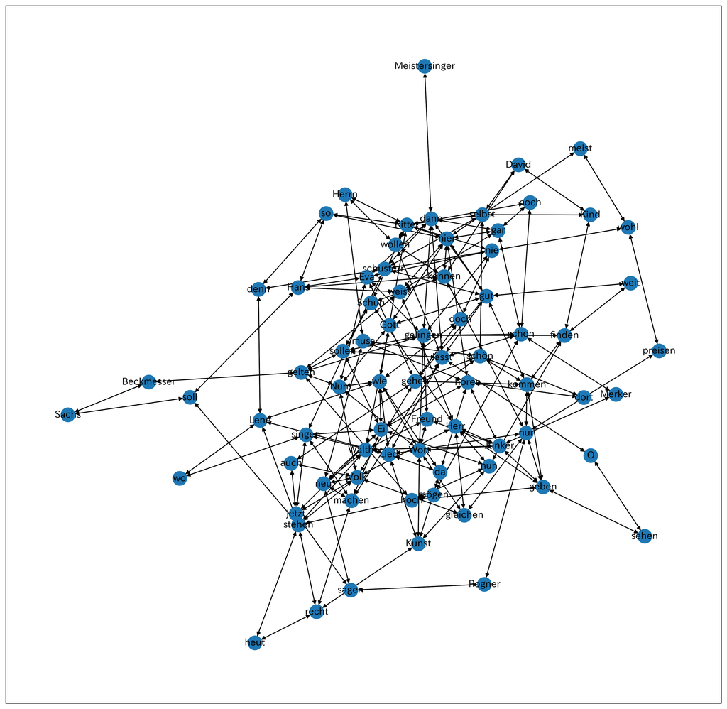

```python
fig = plt.figure(figsize=(16,16), dpi=300)
ax = fig.add_subplot(111)
nx.draw_networkx(graph, with_labels=True, font_weight='bold')
```

### Bokehでインタラクティヴなグラフを作成

[@komo_fr](https://twitter.com/komo_fr)によるPEP解析を参考にした。

```python
output_notebook()
```

```python
plot = Plot(plot_width=800, plot_height=800,
            x_range=Range1d(-2,2), y_range=Range1d(-2,2))
plot.title.text = "Wagner2Vek: Ähnlichkeitgraph von \"Der Meistersinger von Nürnberg\" bei Wort2Vek"

node_hover_tool = HoverTool(tooltips=[("freq", "@freq")])
plot.add_tools(node_hover_tool, TapTool(), BoxSelectTool(), BoxZoomTool(), ResetTool(), WheelZoomTool(), PanTool(), SaveTool())
plot.toolbar.active_scroll = plot.select_one(WheelZoomTool)

graph_renderer = from_networkx(graph, nx.spring_layout, scale=1.5, center=(0,0))

graph_renderer.node_renderer.glyph = Circle(size=15, fill_color='#773280', fill_alpha=0.6, line_color='#773280')
graph_renderer.node_renderer.selection_glyph = Circle(size=15, fill_color=Spectral4[2])
graph_renderer.node_renderer.hover_glyph = Circle(size=15, fill_color='firebrick', fill_alpha=0.6, line_color='firebrick')
graph_renderer.node_renderer.glyph.properties_with_values()

graph_renderer.edge_renderer.glyph = MultiLine(line_color="#CCCCCC", line_alpha=0.8, line_width=5)
graph_renderer.edge_renderer.selection_glyph = MultiLine(line_color=Spectral4[2], line_width=5)
graph_renderer.edge_renderer.hover_glyph = MultiLine(line_color='firebrick', line_alpha=0.6, line_width=5)

graph_renderer.selection_policy = NodesAndLinkedEdges()
graph_renderer.inspection_policy = NodesAndLinkedEdges()

plot.renderers.append(graph_renderer)

x, y = zip(*graph_renderer.layout_provider.graph_layout.values())
source = ColumnDataSource({'x': x, 'y': y,
                           'wort': graph_renderer.node_renderer.data_source.data['index']})
labels = LabelSet(x='x', y='y', text='wort', source=source, text_alpha=0.7)

plot.renderers.append(labels)

show(plot)
```

[interactive chart not shown]

## Next Steps

基本的に会話文であり話者間の方向性があるオペラの歌詞を全て結合して通常のテキストと同様に解析したが、次は話者と相手を考慮して分析・可視化したい。